## Exploratory Data Analysis

### Load Libraries

We load packages for data manipulation (`dplyr`, `tidyr`), visualization (`ggplot2`, `gridExtra`, `ggpubr`), correlation analysis (`corrplot`), and preliminary modeling (`randomForest`). These tools will support all our EDA visualizations and statistical tests.

```r
library(dplyr)
```

```r
library(ggplot2)
library(tidyr)
library(readr)
library(corrplot)
library(gridExtra)
library(ggpubr)
library(randomForest)
```

### Load Dataset

Import the preprocessed dataset (`dataset_preprocessed.csv`) and inspect its structure and summary statistics with `glimpse()` and `summary()`. This ensures the preprocessing steps completed successfully and gives an overview of feature distributions.

```r
df_final <- read_csv("./dataset/dataset_preprocessed.csv")
glimpse(df_final)
```

```
## Rows: 102,554
## Columns: 28
## $ statement            <chr> "End of eviction moratorium means millions of Ame…
## $ tweet                <chr> "@POTUS Biden Blunders - 6 Month Update\n\nInflat…
## $ tweet_clean          <chr> "biden blunders 6 month update inflation delta mi…
## $ truth_label          <lgl> TRUE, TRUE, TRUE, TRUE, TRUE, TRUE, TRUE, TRUE, T…
## $ tweet_word_count     <dbl> 39, 41, 36, 35, 22, 22, 46, 40, 31, 52, 46, 44, 4…
## $ tweet_char_count     <dbl> 266, 261, 221, 225, 162, 131, 269, 248, 190, 276,…
## $ tweet_avg_word_len   <dbl> 6.820513, 6.365854, 6.138889, 6.428571, 7.363636,…
## $ sentiment            <dbl> -0.631584352, -0.452798189, -0.459696186, 0.01311…
## $ sd_sentiment         <dbl> 0.186088375, 0.298648247, 0.469849742, 0.33515617…
## $ flesch               <dbl> -6.288462, 33.334817, 38.165000, -9.316176, -28.5…
## $ unique_count_winsor  <dbl> 1.9660234, -0.2701816, -1.0155832, 0.4752201, 0.4…
## $ present_verbs_winsor <dbl> -0.7197770, 2.2875123, -1.2209918, -0.2185621, 0.…
## $ total_count_winsor   <dbl> 1.0870862, 0.2451331, -1.0177965, -0.1758435, -0.…
## $ past_verbs_winsor    <dbl> -0.4731399, 0.1188717, -1.0651514, 0.1188717, -0.…
## $ adjectives_winsor    <dbl> -1.02070687, -0.51711932, 2.00081843, -0.51711932…
## $ pronouns_winsor      <dbl> -0.3039105, 3.4462437, -0.9289362, 0.3211152, -0.…
## $ exclamation_winsor   <dbl> -0.3345717, -0.3345717, -0.3345717, -0.3345717, -…
## $ questions_winsor     <dbl> 1.003498, -0.427414, -0.427414, 1.003498, -0.4274…
## $ capitals_winsor      <dbl> 1.78588247, 0.14166780, -0.81024596, -0.11794505,…
## $ ampersand_winsor     <dbl> -0.2883093, -0.2883093, -0.2883093, -0.2883093, -…
## $ hashtags_winsor      <dbl> -0.2582129, -0.2582129, -0.2582129, -0.2582129, 5…
## $ followers_count_log  <dbl> 1.09232220, 0.61652054, -1.48511384, -0.65077869,…
## $ friends_count_log    <dbl> 1.09837372, 0.66048739, -0.94788428, -0.57952593,…
## $ statuses_count_log   <dbl> 0.31528133, 0.74605765, -1.07062705, -0.74566392,…
## $ retweets_log         <dbl> 1.6504931, -0.3215114, -0.3215114, -0.3215114, -0…
## $ favourites_log       <dbl> 0.72821827, 0.68833322, -1.18198443, 0.41648207, …
## $ cred                 <dbl> 0.56408706, 0.23544875, -1.29200672, -0.45665198,…
## $ normalize_influence  <dbl> 1.0288017, 0.6405451, -1.4443414, -0.6312987, 0.5…
```

```r
summary(df_final)
```

```
##   statement            tweet           tweet_clean        truth_label
##  Length:102554      Length:102554      Length:102554      Mode :logical
##  Class :character   Class :character   Class :character   FALSE:50764
##  Mode  :character   Mode  :character   Mode  :character   TRUE :51790
##
##
##
##  tweet_word_count tweet_char_count tweet_avg_word_len   sentiment
##  Min.   : 2.0     Min.   : 10      Min.   : 3.545     Min.   :-1.21477
##  1st Qu.:27.0     1st Qu.:152      1st Qu.: 5.289     1st Qu.:-0.15290
##  Median :40.0     Median :229      Median : 5.600     Median :-0.03220
##  Mean   :37.1     Mean   :208      Mean   : 5.649     Mean   :-0.03689
##  3rd Qu.:47.0     3rd Qu.:266      3rd Qu.: 5.957     3rd Qu.: 0.08240
##  Max.   :69.0     Max.   :299      Max.   :11.174     Max.   : 1.02252
##   sd_sentiment        flesch       unique_count_winsor present_verbs_winsor
##  Min.   :0.0000   Min.   :-88.06   Min.   :-1.76098    Min.   :-1.22099
##  1st Qu.:0.1126   1st Qu.: 30.41   1st Qu.:-1.01558    1st Qu.:-0.71978
##  Median :0.2010   Median : 43.59   Median :-0.27018    Median :-0.21856
##  Mean   :0.2257   Mean   : 44.91   Mean   : 0.00569    Mean   : 0.00364
##  3rd Qu.:0.3095   3rd Qu.: 60.05   3rd Qu.: 0.47522    3rd Qu.: 0.78387
##  Max.   :1.5992   Max.   :120.20   Max.   : 2.71143    Max.   : 2.78873
##  total_count_winsor  past_verbs_winsor   adjectives_winsor
##  Min.   :-1.438773   Min.   :-1.065151   Min.   :-1.524294
##  1st Qu.:-0.596820   1st Qu.:-0.473140   1st Qu.:-0.517119
##  Median :-0.175843   Median :-0.473140   Median :-0.013532
##  Mean   : 0.008611   Mean   : 0.006991   Mean   : 0.001543
##  3rd Qu.: 0.666110   3rd Qu.: 0.710883   3rd Qu.: 0.490056
##  Max.   : 3.191969   Max.   : 3.078929   Max.   : 3.007993
##  pronouns_winsor     exclamation_winsor  questions_winsor
##  Min.   :-0.928936   Min.   :-0.334572   Min.   :-0.427414
##  1st Qu.:-0.928936   1st Qu.:-0.334572   1st Qu.:-0.427414
##  Median :-0.303910   Median :-0.334572   Median :-0.427414
##  Mean   : 0.001978   Mean   : 0.002591   Mean   : 0.001829
##  3rd Qu.: 0.321115   3rd Qu.:-0.334572   3rd Qu.:-0.427414
##  Max.   : 3.446244   Max.   : 5.304040   Max.   : 5.296234
##  capitals_winsor     ampersand_winsor    hashtags_winsor
##  Min.   :-0.983321   Min.   :-0.288309   Min.   :-0.258213
##  1st Qu.:-0.550633   1st Qu.:-0.288309   1st Qu.:-0.258213
##  Median :-0.204483   Median :-0.288309   Median :-0.258213
##  Mean   : 0.004561   Mean   : 0.003832   Mean   :-0.005416
##  3rd Qu.: 0.228205   3rd Qu.:-0.288309   3rd Qu.:-0.258213
##  Max.   : 5.766613   Max.   : 4.857735   Max.   : 5.377119
##  followers_count_log friends_count_log   statuses_count_log  retweets_log
##  Min.   :-2.46523    Min.   :-3.371081   Min.   :-4.43621   Min.   :-0.321511
##  1st Qu.:-0.68186    1st Qu.:-0.592749   1st Qu.:-0.59090   1st Qu.:-0.321511
##  Median : 0.01215    Median : 0.080424   Median : 0.08178   Median :-0.321511
##  Mean   :-0.02187    Mean   :-0.008984   Mean   :-0.02296   Mean   :-0.001407
##  3rd Qu.: 0.65496    3rd Qu.: 0.690261   3rd Qu.: 0.66067   3rd Qu.:-0.321511
##  Max.   : 5.48937    Max.   : 3.873778   Max.   : 3.05327   Max.   :15.269207
##  favourites_log          cred          normalize_influence
##  Min.   :-3.21495   Min.   :-1.69654   Min.   :-2.96615
##  1st Qu.:-0.48124   1st Qu.:-0.77883   1st Qu.:-0.63441
##  Median : 0.19237   Median :-0.10804   Median : 0.04542
##  Mean   : 0.01664   Mean   :-0.02716   Mean   :-0.02172
##  3rd Qu.: 0.71093   3rd Qu.: 0.46038   3rd Qu.: 0.65727
##  Max.   : 2.17247   Max.   : 2.48366   Max.   : 5.00090
```

### Label Distribution Analysis

Convert the binary `truth_label` into a factor with levels “False” and “True”. Count the number of tweets in each class and visualize the class balance using a bar chart. This helps identify any class imbalance that may influence modeling decisions.

```r
df_final <- df_final %>%
  mutate(truth_label_factor = factor(truth_label, levels = c(FALSE, TRUE), labels = c("False", "True")))

label_count <- df_final %>%
  group_by(truth_label_factor) %>%
  summarise(count = n())

print(label_count)
```

```
## # A tibble: 2 × 2
##   truth_label_factor count
##   <fct>              <int>
## 1 False              50764
## 2 True               51790
```

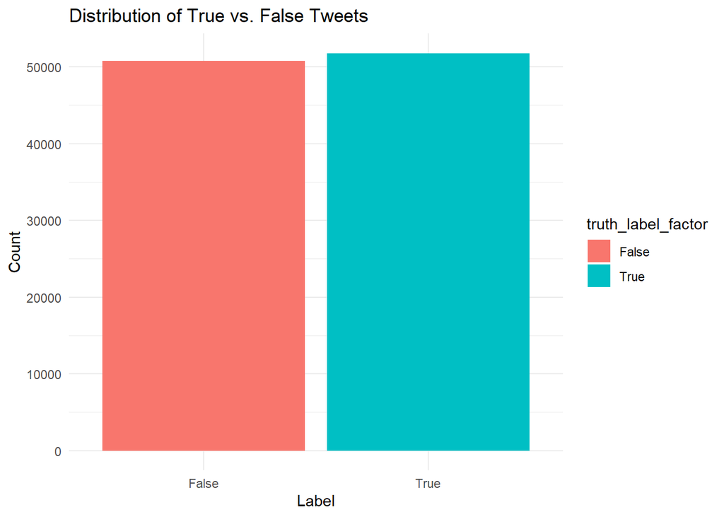

```r
ggplot(label_count, aes(x = truth_label_factor, y = count, fill = truth_label_factor)) +
  geom_bar(stat = "identity") +
  theme_minimal() +
  labs(title = "Distribution of True vs. False Tweets", x = "Label", y = "Count")
```

### Text Length Exploratory Analysis

- **Character Count Histogram**: Plot the distribution of `tweet_char_count` to understand overall tweet length in characters.
- **Word Count Histogram**: Plot the distribution of `tweet_word_count` to inspect token-level length.  
  Arrange these two histograms side by side to compare length patterns at different granularity levels.

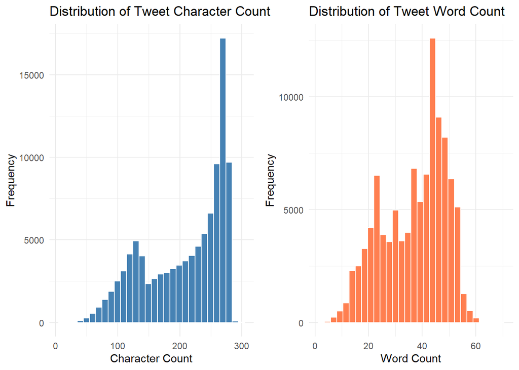

```r
p1 <- ggplot(df_final, aes(x = tweet_char_count)) +
  geom_histogram(bins = 30, fill = "steelblue", color = "white") +
  theme_minimal() +
  labs(title = "Distribution of Tweet Character Count", x = "Character Count", y = "Frequency")

p2 <- ggplot(df_final, aes(x = tweet_word_count)) +
  geom_histogram(bins = 30, fill = "coral", color = "white") +
  theme_minimal() +
  labs(title = "Distribution of Tweet Word Count", x = "Word Count", y = "Frequency")

grid.arrange(p1, p2, ncol = 2)
```

### Comparison of Tweet Length by Label

Use a horizontal boxplot of `tweet_word_count` grouped by `truth_label` to compare word counts between true and false tweets. This reveals whether one class tends to have systematically longer or shorter tweets.

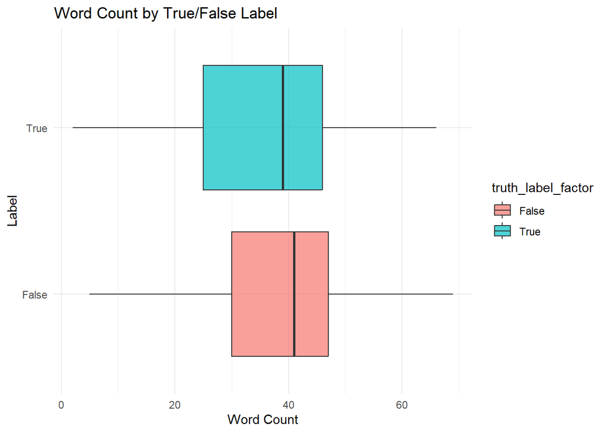

```r
ggplot(df_final, aes(x = truth_label_factor, y = tweet_word_count, fill = truth_label_factor)) +
  geom_boxplot(outlier.shape = NA, alpha = 0.7) +
  theme_minimal() +
  coord_flip() +
  labs(title = "Word Count by True/False Label", x = "Label", y = "Word Count")
```

### Sentiment and Readability Analysis

- **Readability Distribution**: Display a histogram of the Flesch score (`flesch`) to assess text complexity across all tweets.
- **Sentiment Density by Label**: Overlay density plots of average sentiment by label to examine differences in emotional tone between true and false tweets.

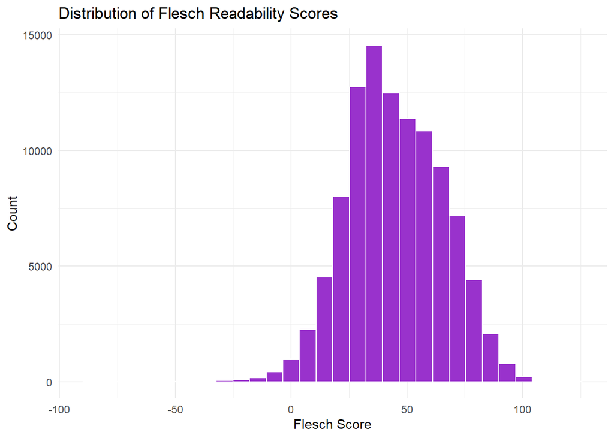

```r
ggplot(df_final, aes(x = flesch)) +
  geom_histogram(fill = "darkorchid", bins = 30, color = "white") +
  theme_minimal() +
  labs(title = "Distribution of Flesch Readability Scores", x = "Flesch Score", y = "Count")
```

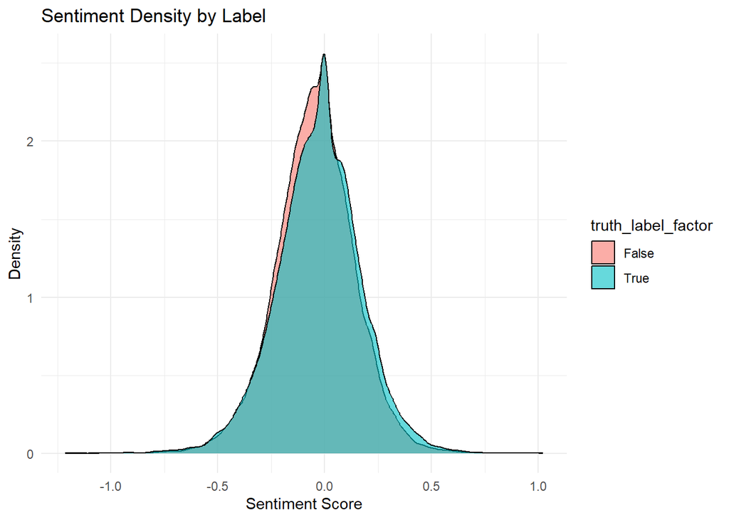

```r
ggplot(df_final, aes(x = sentiment, fill = truth_label_factor)) +
  geom_density(alpha = 0.6) +
  theme_minimal() +
  labs(title = "Sentiment Density by Label", x = "Sentiment Score", y = "Density")
```

### Summary Statistics of Length, Sentiment, and Readability

Calculate overall and per-label summary statistics (mean, median, standard deviation) for `tweet_char_count`, `tweet_word_count`, `sentiment`, and `flesch`. Round results for clarity. These tables quantify observed differences and provide context for subsequent tests.

```r
tweet_length_overall <- df_final %>%
  summarise(
    mean_char = mean(tweet_char_count, na.rm = TRUE),
    median_char = median(tweet_char_count, na.rm = TRUE),
    sd_char = sd(tweet_char_count, na.rm = TRUE),
    mean_word = mean(tweet_word_count, na.rm = TRUE),
    median_word = median(tweet_word_count, na.rm = TRUE),
    sd_word = sd(tweet_word_count, na.rm = TRUE)
  ) %>%
  mutate(across(where(is.numeric), ~ round(.x, 2)))
cat("Overall Tweet Length Statistics:\n")
```

```
## Overall Tweet Length Statistics:
```

```r
print(tweet_length_overall)
```

```
## # A tibble: 1 × 6
##   mean_char median_char sd_char mean_word median_word sd_word
##       <dbl>       <dbl>   <dbl>     <dbl>       <dbl>   <dbl>
## 1      208.         229    63.5      37.1          40    11.7
```

```r
tweet_length_by_label <- df_final %>%
  group_by(truth_label_factor) %>%
  summarise(
    mean_char = mean(tweet_char_count, na.rm = TRUE),
    median_char = median(tweet_char_count, na.rm = TRUE),
    sd_char = sd(tweet_char_count, na.rm = TRUE),
    mean_word = mean(tweet_word_count, na.rm = TRUE),
    median_word = median(tweet_word_count, na.rm = TRUE),
    sd_word = sd(tweet_word_count, na.rm = TRUE)
  ) %>%
  mutate(across(where(is.numeric), ~ round(.x, 2)))
cat("Tweet Length Statistics by Label:\n")
```

```
## Tweet Length Statistics by Label:
```

```r
print(tweet_length_by_label)
```

```
## # A tibble: 2 × 7
##   truth_label_factor mean_char median_char sd_char mean_word median_word sd_word
##   <fct>                  <dbl>       <dbl>   <dbl>     <dbl>       <dbl>   <dbl>
## 1 False                   214.         234    60.7      38.3          41    11.3
## 2 True                    203.         222    65.7      35.9          39    12.0
```

```r
sentiment_stats_by_label <- df_final %>%
  group_by(truth_label_factor) %>%
  summarise(
    mean_sentiment = mean(sentiment, na.rm = TRUE),
    median_sentiment = median(sentiment, na.rm = TRUE),
    sd_sentiment = sd(sentiment, na.rm = TRUE),
    mean_flesch = mean(flesch, na.rm = TRUE),
    median_flesch = median(flesch, na.rm = TRUE),
    sd_flesch = sd(flesch, na.rm = TRUE)
  ) %>%
  mutate(across(where(is.numeric), ~ round(.x, 2)))
cat("Sentiment and Readability Statistics by Label:\n")
```

```
## Sentiment and Readability Statistics by Label:
```

```r
print(sentiment_stats_by_label)
```

```
## # A tibble: 2 × 7
##   truth_label_factor mean_sentiment median_sentiment sd_sentiment mean_flesch
##   <fct>                       <dbl>            <dbl>        <dbl>       <dbl>
## 1 False                       -0.05            -0.04         0.18        45.7
## 2 True                        -0.03            -0.02         0.2         44.2
## # ℹ 2 more variables: median_flesch <dbl>, sd_flesch <dbl>
```

### T-Tests for Sentiment and Word Count

Perform independent t-tests comparing `sentiment` and `tweet_word_count` between true and false tweets. These tests determine whether observed differences in tone or length are statistically significant.

```r
t.test(sentiment ~ truth_label_factor, data = df_final)
```

```
##
##  Welch Two Sample t-test
##
## data:  sentiment by truth_label_factor
## t = -13.665, df = 102306, p-value < 2.2e-16
## alternative hypothesis: true difference in means between group False and group True is not equal to 0
## 95 percent confidence interval:
##  -0.01840655 -0.01378864
## sample estimates:
## mean in group False  mean in group True
##         -0.04501925         -0.02892166
```

```r
t.test(tweet_word_count ~ truth_label_factor, data = df_final)
```

```
##
##  Welch Two Sample t-test
##
## data:  tweet_word_count by truth_label_factor
## t = 33.618, df = 102397, p-value < 2.2e-16
## alternative hypothesis: true difference in means between group False and group True is not equal to 0
## 95 percent confidence interval:
##  2.301585 2.586571
## sample estimates:
## mean in group False  mean in group True
##            38.33510            35.89102
```

### Punctuation Usage Comparison

1. Compute group-wise mean, median, and SD for `exclamation_winsor` and `questions_winsor`.
2. Visualize each with a horizontal boxplot by label to compare distributions.
3. Conduct t-tests to assess whether the differences in punctuation usage are significant.
4. Arrange the exclamation and question plots vertically for clear comparison.  
   This analysis identifies whether punctuation patterns differ systematically across classes.

```r
excl_stats <- df_final %>%
  group_by(truth_label_factor) %>%
  summarise(
    mean_exclamation = mean(exclamation_winsor, na.rm = TRUE),
    median_exclamation = median(exclamation_winsor, na.rm = TRUE),
    sd_exclamation = sd(exclamation_winsor, na.rm = TRUE)
  )
print(excl_stats)
```

```
## # A tibble: 2 × 4
##   truth_label_factor mean_exclamation median_exclamation sd_exclamation
##   <fct>                         <dbl>              <dbl>          <dbl>
## 1 False                        0.0767             -0.335          1.12
## 2 True                        -0.0700             -0.335          0.870
```

```r
p_exclamation <- ggplot(df_final, aes(x = truth_label_factor, y = exclamation_winsor, fill = truth_label_factor)) +
  geom_boxplot(alpha = 0.7) +
  theme_minimal() +
  coord_flip() +
  labs(title = "Exclamation Usage (Winsorized & Normalized) by Label",
       x = "Label", y = "Exclamations (winsor)") +
  scale_fill_manual(values = c("0" = "orange", "1" = "forestgreen"))

t_exclamation <- t.test(exclamation_winsor ~ truth_label_factor, data = df_final)
print(t_exclamation)
```

```
##
##  Welch Two Sample t-test
##
## data:  exclamation_winsor by truth_label_factor
## t = 23.443, df = 95886, p-value < 2.2e-16
## alternative hypothesis: true difference in means between group False and group True is not equal to 0
## 95 percent confidence interval:
##  0.1344005 0.1589242
## sample estimates:
## mean in group False  mean in group True
##          0.07665573         -0.07000661
```

```r
quest_stats <- df_final %>%
  group_by(truth_label_factor) %>%
  summarise(
    mean_questions = mean(questions_winsor, na.rm = TRUE),
    median_questions = median(questions_winsor, na.rm = TRUE),
    sd_questions = sd(questions_winsor, na.rm = TRUE)
  )
print(quest_stats)
```

```
## # A tibble: 2 × 4
##   truth_label_factor mean_questions median_questions sd_questions
##   <fct>                       <dbl>            <dbl>        <dbl>
## 1 False                      0.0462           -0.427        1.05
## 2 True                      -0.0417           -0.427        0.945
```

```r
p_questions <- ggplot(df_final, aes(x = truth_label_factor, y = questions_winsor, fill = truth_label_factor)) +
  geom_boxplot(alpha = 0.7) +
  theme_minimal() +
  coord_flip() +
  labs(title = "Question Usage (Winsorized & Normalized) by Label",
       x = "Label", y = "Questions (winsor)") +
  scale_fill_manual(values = c("0" = "orange", "1" = "forestgreen"))

t_questions <- t.test(questions_winsor ~ truth_label_factor, data = df_final)
print(t_questions)
```

```
##
##  Welch Two Sample t-test
##
## data:  questions_winsor by truth_label_factor
## t = 14.048, df = 100851, p-value < 2.2e-16
## alternative hypothesis: true difference in means between group False and group True is not equal to 0
## 95 percent confidence interval:
##  0.07564062 0.10016944
## sample estimates:
## mean in group False  mean in group True
##          0.04622111         -0.04168391
```

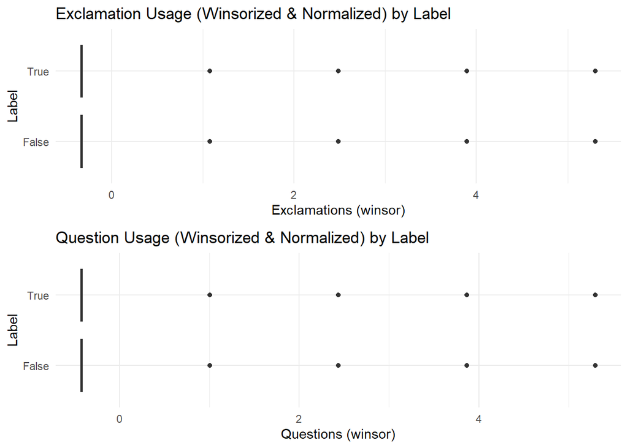

```r
gridExtra::grid.arrange(p_exclamation, p_questions, ncol = 1)
```

### User Socialisation Features EDA

Summarize user metrics (`followers_count_log`, `friends_count_log`, `cred`, `normalize_influence`) by label, reporting means and medians. Plot density curves for each metric to visualize distributional differences between true and false tweet authors. Use Wilcoxon rank-sum tests to verify significance under non-normality.

```r
user_feature_summary <- df_final %>%
  group_by(truth_label_factor) %>%
  summarise(
    mean_followers  = mean(followers_count_log),
    median_followers = median(followers_count_log),
    mean_friends    = mean(friends_count_log),
    median_friends  = median(friends_count_log),
    mean_cred       = mean(cred),
    median_cred     = median(cred),
    mean_influence  = mean(normalize_influence),
    median_influence= median(normalize_influence),
    n = n()
  )

user_feature_summary
```

```
## # A tibble: 2 × 10
##   truth_label_factor mean_followers median_followers mean_friends median_friends
##   <fct>                       <dbl>            <dbl>        <dbl>          <dbl>
## 1 False                      -0.155           -0.117      -0.0952        -0.0245
## 2 True                        0.109            0.127       0.0755         0.171
## # ℹ 5 more variables: mean_cred <dbl>, median_cred <dbl>, mean_influence <dbl>,
## #   median_influence <dbl>, n <int>
```

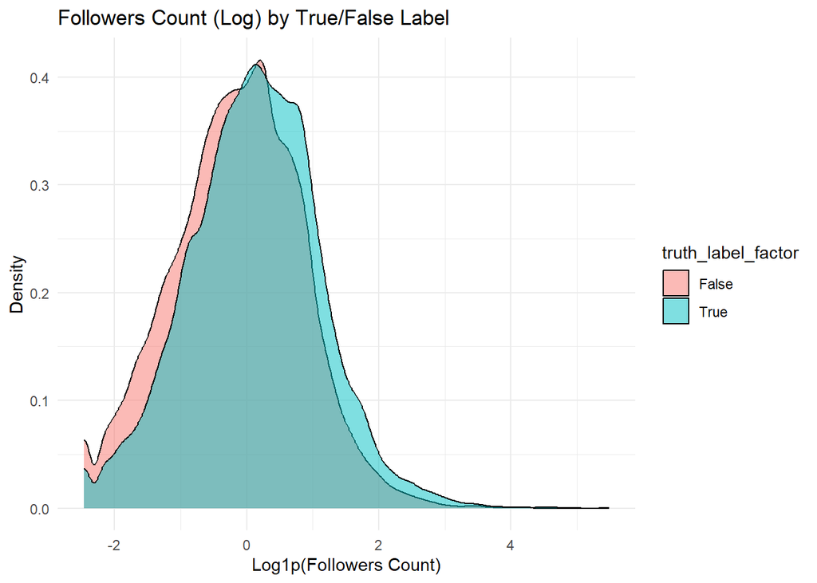

```r
ggplot(df_final, aes(x = followers_count_log, fill = truth_label_factor)) +
  geom_density(alpha = 0.5) +
  theme_minimal() +
  labs(title = "Followers Count (Log) by True/False Label", x = "Log1p(Followers Count)", y = "Density")
```

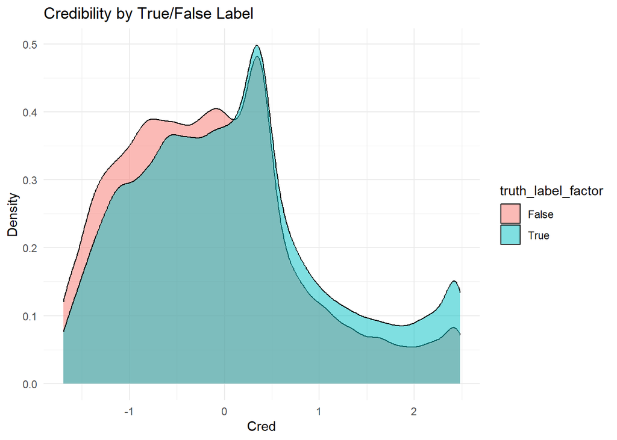

```r
ggplot(df_final, aes(x = cred, fill = truth_label_factor)) +
  geom_density(alpha = 0.5) +
  theme_minimal() +
  labs(title = "Credibility by True/False Label", x = "Cred", y = "Density")
```

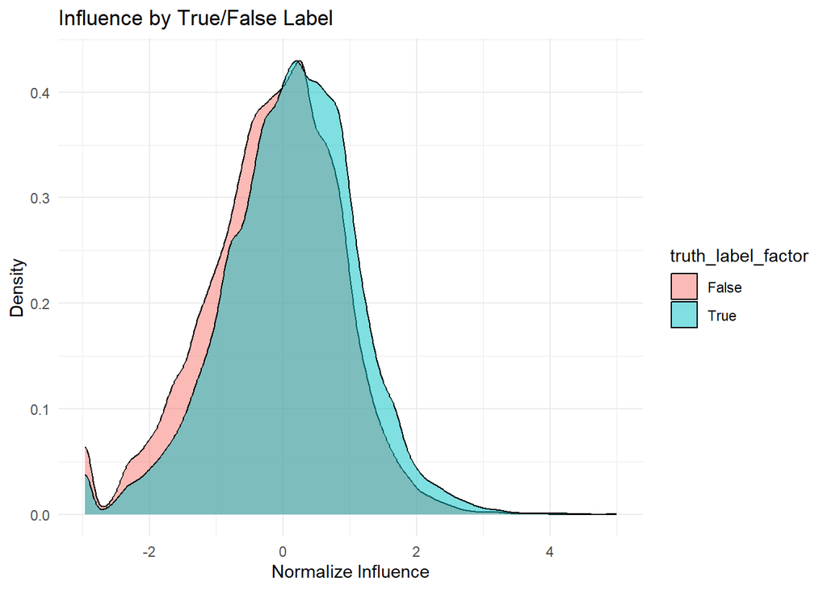

```r
ggplot(df_final, aes(x = normalize_influence, fill = truth_label_factor)) +
  geom_density(alpha = 0.5) +
  theme_minimal() +
  labs(title = "Influence by True/False Label", x = "Normalize Influence", y = "Density")
```

```r
wilcox.test(followers_count_log ~ truth_label_factor, data = df_final)
```

```
##
##  Wilcoxon rank sum test with continuity correction
##
## data:  followers_count_log by truth_label_factor
## W = 1121499365, p-value < 2.2e-16
## alternative hypothesis: true location shift is not equal to 0
```

```r
wilcox.test(cred ~ truth_label_factor, data = df_final)
```

```
##
##  Wilcoxon rank sum test with continuity correction
##
## data:  cred by truth_label_factor
## W = 1163632598, p-value < 2.2e-16
## alternative hypothesis: true location shift is not equal to 0
```

```r
wilcox.test(normalize_influence ~ truth_label_factor, data = df_final)
```

```
##
##  Wilcoxon rank sum test with continuity correction
##
## data:  normalize_influence by truth_label_factor
## W = 1121401455, p-value < 2.2e-16
## alternative hypothesis: true location shift is not equal to 0
```

### Feature Correlation Analysis

Select key numeric features and compute their Pearson correlation matrix. Display it as a clustered heatmap using `corrplot`. This reveals multicollinearity and guides feature selection for downstream modeling.

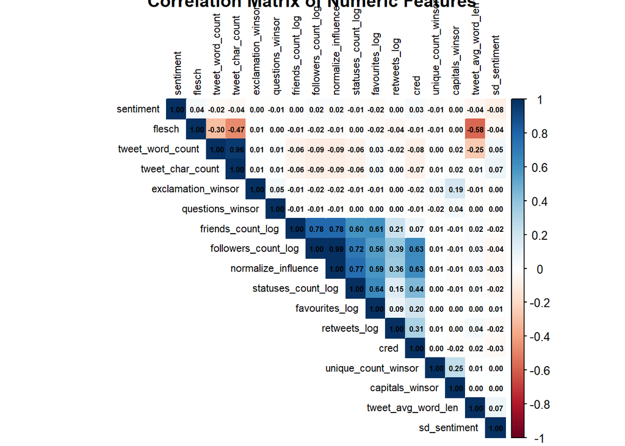

```r
num_cols_for_corr <- c(
  "tweet_word_count", "tweet_char_count", "tweet_avg_word_len",
  "sentiment", "sd_sentiment", "flesch",
  "unique_count_winsor", "exclamation_winsor", "questions_winsor", "capitals_winsor",
  "followers_count_log", "friends_count_log", "statuses_count_log",
  "retweets_log", "favourites_log", "cred", "normalize_influence"
)

df_num <- df_final[, num_cols_for_corr]
corr_matrix <- cor(df_num, use = "complete.obs", method = "pearson")
corrplot(corr_matrix, method = "color", type = "upper",
         tl.cex = 0.7, tl.col = "black", order = "hclust",
         title = "Correlation Matrix of Numeric Features",
         addCoef.col = "black", number.cex = 0.5)
```

### Random Forest Importance Estimation

To get preliminary feature importance: 1. Sample 10% of the data for faster training.  
2. Train a random forest with 100 trees on text-derived and user features.  
3. Extract `MeanDecreaseAccuracy` and `MeanDecreaseGini` metrics.  
4. Rank features by each metric, compute an average rank, and sort.  
5. Visualize importance rankings and the two individual metrics with horizontal bar charts.  
This step surfaces the most predictive variables and informs our baseline and deep models.

```r
df_eda_rf <- df_final %>%
  mutate(truth_label_factor = factor(truth_label_factor, levels = c("False", "True")))

set.seed(42)
df_eda_sample <- df_eda_rf %>%
  sample_frac(0.1)

rf_model <- randomForest(
  truth_label_factor ~ tweet_word_count + tweet_char_count + tweet_avg_word_len +
    sentiment + sd_sentiment + flesch +
    unique_count_winsor + exclamation_winsor + questions_winsor + capitals_winsor +
    followers_count_log + friends_count_log + statuses_count_log + retweets_log + favourites_log +
    cred + normalize_influence,
  data = df_eda_sample,
  ntree = 100,
  importance = TRUE
)

imp_mat <- importance(rf_model)
print(imp_mat)
```

```
##                        False       True MeanDecreaseAccuracy MeanDecreaseGini
## tweet_word_count    3.339379  7.1397007            10.274339        278.64203
## tweet_char_count    4.652568 12.2003822            15.382767        364.58424
## tweet_avg_word_len  5.638754  3.4517041             7.381091        369.46021
## sentiment           6.003170  1.2217948             4.995202        389.73754
## sd_sentiment        6.012617  2.1998550             5.989234        376.82000
## flesch              3.939844  7.4075926             9.193046        391.01561
## unique_count_winsor 5.290824  1.8002785             4.950081        171.50456
## exclamation_winsor  3.323556  5.0516838             6.096598         58.37808
## questions_winsor    1.632287  2.1126752             2.807773         74.16754
## capitals_winsor     5.460001  3.6679478             6.652466        313.38966
## followers_count_log 8.709435  2.1586944            14.997015        355.55432
## friends_count_log   7.792402  1.6429551            12.237021        383.81512
## statuses_count_log  4.863250  6.4301535            10.037540        385.23318
## retweets_log        6.908714 -3.9216695             2.134078         74.98517
## favourites_log      9.363398  0.4026795             9.445446        397.81940
## cred                4.451721  5.4923384            11.493804        366.83057
## normalize_influence 8.080078  1.9438072            14.697099        374.88850
```

```r
imp_df <- as.data.frame(imp_mat)
imp_df$Feature <- rownames(imp_df)

imp_df <- imp_df %>%
  mutate(
    rank_accuracy = rank(-MeanDecreaseAccuracy),
    rank_gini = rank(-MeanDecreaseGini),
    avg_rank = (rank_accuracy + rank_gini) / 2
  ) %>%
  arrange(avg_rank)

print("Importance:")
```

```
## [1] "Importance:"
```

```r
print(imp_df[, c("Feature", "MeanDecreaseAccuracy", "MeanDecreaseGini", "rank_accuracy", "rank_gini", "avg_rank")])
```

```
##                                 Feature MeanDecreaseAccuracy MeanDecreaseGini
## friends_count_log     friends_count_log            12.237021        383.81512
## favourites_log           favourites_log             9.445446        397.81940
## normalize_influence normalize_influence            14.697099        374.88850
## tweet_char_count       tweet_char_count            15.382767        364.58424
## flesch                           flesch             9.193046        391.01561
## statuses_count_log   statuses_count_log            10.037540        385.23318
## followers_count_log followers_count_log            14.997015        355.55432
## cred                               cred            11.493804        366.83057
## sentiment                     sentiment             4.995202        389.73754
## tweet_avg_word_len   tweet_avg_word_len             7.381091        369.46021
## tweet_word_count       tweet_word_count            10.274339        278.64203
## sd_sentiment               sd_sentiment             5.989234        376.82000
## capitals_winsor         capitals_winsor             6.652466        313.38966
## unique_count_winsor unique_count_winsor             4.950081        171.50456
## exclamation_winsor   exclamation_winsor             6.096598         58.37808
## questions_winsor       questions_winsor             2.807773         74.16754
## retweets_log               retweets_log             2.134078         74.98517
##                     rank_accuracy rank_gini avg_rank
## friends_count_log               4         5      4.5
## favourites_log                  8         1      4.5
## normalize_influence             3         7      5.0
## tweet_char_count                1        10      5.5
## flesch                          9         2      5.5
## statuses_count_log              7         4      5.5
## followers_count_log             2        11      6.5
## cred                            5         9      7.0
## sentiment                      14         3      8.5
## tweet_avg_word_len             10         8      9.0
## tweet_word_count                6        13      9.5
## sd_sentiment                   13         6      9.5
## capitals_winsor                11        12     11.5
## unique_count_winsor            15        14     14.5
## exclamation_winsor             12        17     14.5
## questions_winsor               16        16     16.0
## retweets_log                   17        15     16.0
```

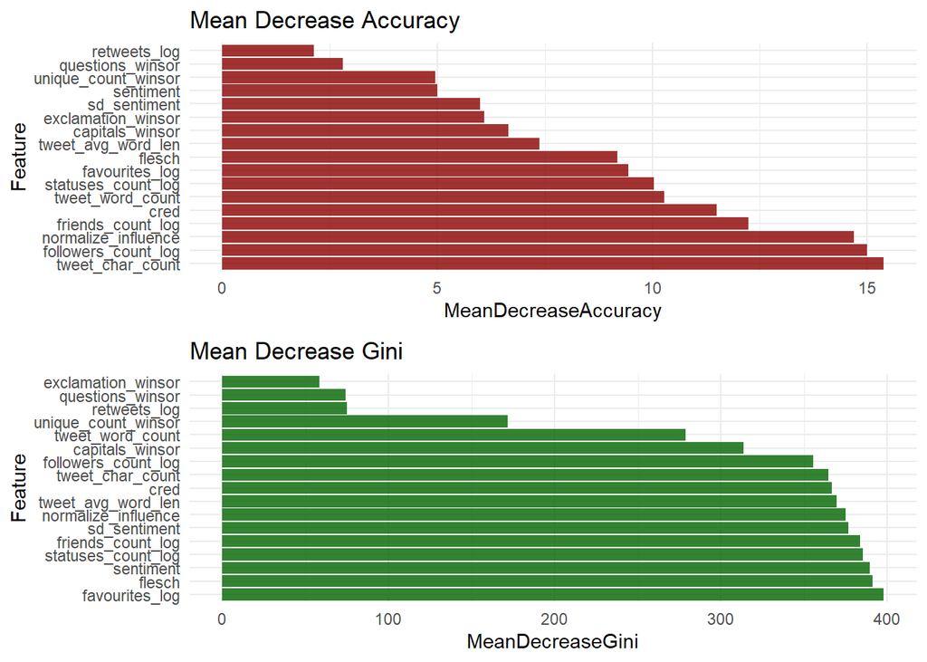

```r
p_importance <- ggplot(imp_df, aes(x = reorder(Feature, -avg_rank), y = avg_rank)) +
  geom_bar(stat = "identity", fill = "steelblue", alpha = 0.8) +
  coord_flip() +
  labs(title = "Importance Ranking", x = "Feature", y = "Average Rank (Lower is More Important)") +
  theme_minimal()

p_accuracy <- ggplot(imp_df, aes(x = reorder(Feature, -MeanDecreaseAccuracy), y = MeanDecreaseAccuracy)) +
  geom_bar(stat = "identity", fill = "darkred", alpha = 0.8) +
  coord_flip() +
  labs(title = "Mean Decrease Accuracy", x = "Feature", y = "MeanDecreaseAccuracy") +
  theme_minimal()

p_gini <- ggplot(imp_df, aes(x = reorder(Feature, -MeanDecreaseGini), y = MeanDecreaseGini)) +
  geom_bar(stat = "identity", fill = "darkgreen", alpha = 0.8) +
  coord_flip() +
  labs(title = "Mean Decrease Gini", x = "Feature", y = "MeanDecreaseGini") +
  theme_minimal()

gridExtra::grid.arrange(p_accuracy, p_gini, ncol = 1)
```

### Final Importance Ranking Visualization

Present a consolidated bar chart of average feature ranks, highlighting which features the random forest found most informative. This guides our feature selection strategy going forward.

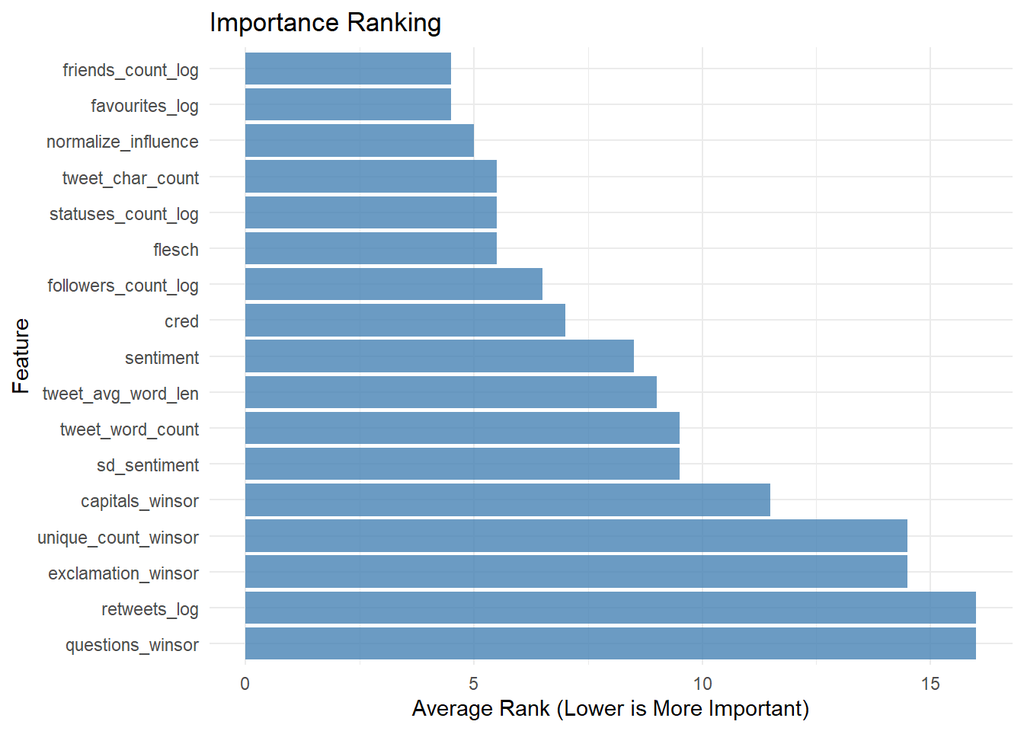

```r
gridExtra::grid.arrange(p_importance, ncol = 1)
```